# Praca domowa 2

Aleksandra Palka

2022-10-18

*Funkcje*

**ZADANIE 1**

Tworzę próbę składającą się z trzech elementów

```r
x <- sample(1:10, 3, replace = TRUE)
n <- 3
```

Wartości dla próby o wielkości 3 wynoszą 10, 1, 5. Tworzę cztery funkcje, ktore wyznaczaja estymatory odchylenia standardowego

```r
funkcjajeden <- function(x){
  est1  = sqrt(1/n *  sum(x - mean(x))^2)
  return(est1)
}
```

```r
funkcjadwa <- function(x){
  est2 = sqrt(1/n-1 * sum(x- mean(x)^2))
  return(est2)
}
```

```r
funkcjatrzy <- function(x){
  est3 = 1/n * sum(abs(x-mean(x)))
  return(est3)
}
```

```r
funkcjacztery <- function(x){
  est4 = (1/(n-1)) * sum(abs(x-mean(x)))
  return(est4)
}
```

Odchylenie standardowe dla danej próby wynosi 4.5092498.

Tworzę dwa wektory (x to wektor oznaczający funkcje 1-4 oraz odchylenie standardowe(5), a wektor y posiada wartości tych funkcji i odchylenia)

```r
y <- c(funkcjajeden(x), funkcjadwa(x), funkcjatrzy(x), funkcjacztery(x), sd(x))
x <- c(1, 2, 3, 4, 5)
y
```

```
## [1] 5.127900e-16 8.346656e+00 3.111111e+00 4.666667e+00 4.509250e+00
```

```r
x
```

```
## [1] 1 2 3 4 5
```

Tworzę wykres pokazujący jak daleko znajdują się wartości funkcji od wartości odchylenia standardowego

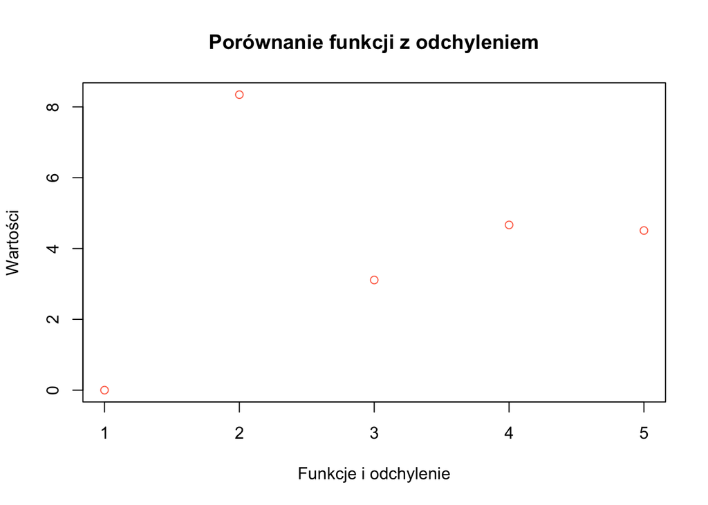

```r
plot(y~x, xlab = "Funkcje i odchylenie", ylab = "Wartości", main = "Porównanie funkcji z odchyleniem", col = "coral1")
```

Numery od 1 do 4 to numery funkcji, zaś 5 odpowiada odchyleniu standardowemu.

**ZADANIE 2**

Buduję zestaw danych

```r
oceny <- c(1,2,1,1,2,3,2,3,1,2,3,3,2,3,1)
factor(oceny)
```

```
##  [1] 1 2 1 1 2 3 2 3 1 2 3 3 2 3 1
## Levels: 1 2 3
```

```r
levels(oceny) <- c("zle", "srednio", "dobrze")
oceny
```

```
##  [1] 1 2 1 1 2 3 2 3 1 2 3 3 2 3 1
## attr(,"levels")
## [1] "zle"     "srednio" "dobrze"
```

Tworzę funkcję, która wyznacza średnią, odchylenie standardowe i współczynnik zmienności dla zestawu danych

```r
wyniki <- function(oceny){
  sr <- mean(oceny)
  os <- sd(oceny)
  wzm <- sd(oceny)/mean(oceny)
  return(list(srednia=sr, odchylenie=os, wspzmiennosci=wzm ))
  }
```

Oto otrzymane wyniki:

```r
wyniki(oceny)
```

```
## $srednia
## [1] 2
##
## $odchylenie
## [1] 0.8451543
##
## $wspzmiennosci
## [1] 0.4225771
```

*Własności pakietu dplyr*

Wczytuję pakiety tidyr, dplyr oraz gapminder

```r
library(tidyr)
library(dplyr)
library(gapminder)
```

**ZADANIE 3**

Podpunkt a

Zmieniam nazwy dwóch zmiennych na polskie

```r
kraje <- gapminder %>%
  select(country:gdpPercap, PKB = gdpPercap, rok = year)
```

Można zauważyć zmianę nazw dwóch kolumn

```r
kraje
```

```
## # A tibble: 1,704 × 6
##    country     continent   rok lifeExp      pop   PKB
##    <fct>       <fct>     <int>   <dbl>    <int> <dbl>
##  1 Afghanistan Asia       1952    28.8  8425333  779.
##  2 Afghanistan Asia       1957    30.3  9240934  821.
##  3 Afghanistan Asia       1962    32.0 10267083  853.
##  4 Afghanistan Asia       1967    34.0 11537966  836.
##  5 Afghanistan Asia       1972    36.1 13079460  740.
##  6 Afghanistan Asia       1977    38.4 14880372  786.
##  7 Afghanistan Asia       1982    39.9 12881816  978.
##  8 Afghanistan Asia       1987    40.8 13867957  852.
##  9 Afghanistan Asia       1992    41.7 16317921  649.
## 10 Afghanistan Asia       1997    41.8 22227415  635.
## # … with 1,694 more rows
```

Podpunkt b

Dodaję populację liczoną w milionach

```r
kraje <- gapminder %>%
  mutate(pop_mln = pop/1000000)
```

Tak prezentuje się kolumna z danymi o populacji liczonej w milionach:

```r
kraje
```

```
## # A tibble: 1,704 × 7
##    country     continent  year lifeExp      pop gdpPercap pop_mln
##    <fct>       <fct>     <int>   <dbl>    <int>     <dbl>   <dbl>
##  1 Afghanistan Asia       1952    28.8  8425333      779.    8.43
##  2 Afghanistan Asia       1957    30.3  9240934      821.    9.24
##  3 Afghanistan Asia       1962    32.0 10267083      853.   10.3
##  4 Afghanistan Asia       1967    34.0 11537966      836.   11.5
##  5 Afghanistan Asia       1972    36.1 13079460      740.   13.1
##  6 Afghanistan Asia       1977    38.4 14880372      786.   14.9
##  7 Afghanistan Asia       1982    39.9 12881816      978.   12.9
##  8 Afghanistan Asia       1987    40.8 13867957      852.   13.9
##  9 Afghanistan Asia       1992    41.7 16317921      649.   16.3
## 10 Afghanistan Asia       1997    41.8 22227415      635.   22.2
## # … with 1,694 more rows
```

**ZADANIE 4**

Wyświetlam kraje w Afryce, które w 1957 roku miały PKB na osobę wynoszące powyżej 1200$

```r
Afryka <- gapminder %>%
select(year, gdpPercap, country, continent) %>%
filter(year == 1957, gdpPercap > 1200, continent == "Africa" )
```

Lista krajów, które spełniają powyższe warunki:

```r
Afryka
```

```
## # A tibble: 23 × 4
##     year gdpPercap country       continent
##    <int>     <dbl> <fct>         <fct>
##  1  1957     3014. Algeria       Africa
##  2  1957     3828. Angola        Africa
##  3  1957     1313. Cameroon      Africa
##  4  1957     1308. Chad          Africa
##  5  1957     1211. Comoros       Africa
##  6  1957     2315. Congo, Rep.   Africa
##  7  1957     1501. Cote d'Ivoire Africa
##  8  1957     2865. Djibouti      Africa
##  9  1957     1459. Egypt         Africa
## 10  1957     4976. Gabon         Africa
## # … with 13 more rows
```

Wykres pokazujący te kraje oraz ich PKB

```r
library(ggplot2)
```

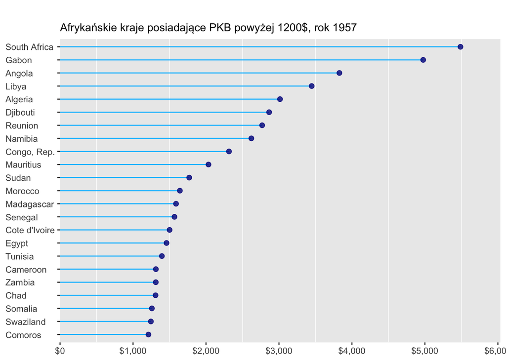

```r
df <- gapminder %>%
  filter(year == 1957 & continent == "Africa", gdpPercap > 1200) %>%
  arrange(gdpPercap) %>%
  mutate(country = factor(country, levels = country))

ggplot(df, aes(x = gdpPercap, y = country)) +
  geom_segment(aes(x = 0, xend = gdpPercap,
                   y = country, yend = country),
               colour = "deepskyblue1") +
  geom_point(colour = "darkblue", size = 2, alpha = 0.8) +
  scale_x_continuous(expand = c(0, 0),
                     limits = c(0, max(df$gdpPercap) * 1.1),
                     labels = scales::dollar) +
  labs(title = "",
       subtitle = "Afrykańskie kraje posiadające PKB powyżej 1200$, rok 1957",
       x = NULL,
       y = NULL,
       fill = NULL) +

  theme(panel.grid.major = element_blank(),
        axis.text.y = element_text(hjust = 0))
```

**ZADANIE 5**

Pokazuję, które kraje (pomijając kraje w Afryce) miały PKB mniejsze od 750$ (w roku 1962)

```r
innekraje <- gapminder %>%
filter(year == 1962, gdpPercap < 750,
       continent %in% c("Americas", "Europe", "Asia"))
```

Oto lista tych krajów:

```r
innekraje
```

```
## # A tibble: 6 × 6
##   country    continent  year lifeExp       pop gdpPercap
##   <fct>      <fct>     <int>   <dbl>     <int>     <dbl>
## 1 Bangladesh Asia       1962    41.2  56839289      686.
## 2 Cambodia   Asia       1962    43.4   6083619      497.
## 3 China      Asia       1962    44.5 665770000      488.
## 4 India      Asia       1962    43.6 454000000      658.
## 5 Myanmar    Asia       1962    45.1  23634436      388
## 6 Nepal      Asia       1962    39.4  10332057      652.
```

**ZADANIE 6**

Sprawdzam ile wynosiła przeciętna długość życia w Polsce w 1952, 1977 oraz w 2002

```r
polskazycie <- gapminder %>%
  select(year, country, lifeExp)  %>%
  filter(country == "Poland", year %in% c("1952", "1977", "2002"))
```

Tak prezentuje się lista:

```r
polskazycie
```

```
## # A tibble: 3 × 3
##    year country lifeExp
##   <int> <fct>     <dbl>
## 1  1952 Poland     61.3
## 2  1977 Poland     70.7
## 3  2002 Poland     74.7
```

W których krajach oczekiwana długość życia była większa w 1952 roku?

```r
amerykazycie52 <- gapminder %>%
  select(year, country, continent, lifeExp) %>%
  filter(continent == "Americas", year == 1952 , lifeExp > 61.31)
```

Tak prezentują się wyniki:

```r
amerykazycie52
```

```
## # A tibble: 6 × 4
##    year country       continent lifeExp
##   <int> <fct>         <fct>       <dbl>
## 1  1952 Argentina     Americas     62.5
## 2  1952 Canada        Americas     68.8
## 3  1952 Paraguay      Americas     62.6
## 4  1952 Puerto Rico   Americas     64.3
## 5  1952 United States Americas     68.4
## 6  1952 Uruguay       Americas     66.1
```

W których krajach oczekiwana długość życia była większa w 1977 roku?

```r
amerykazycie77 <- gapminder %>%
  select(year, country, continent, lifeExp) %>%
  filter(continent == "Americas", year == 1977 , lifeExp > 70.67)
```

Oto lista krajów:

```r
amerykazycie77
```

```
## # A tibble: 5 × 4
##    year country       continent lifeExp
##   <int> <fct>         <fct>       <dbl>
## 1  1977 Canada        Americas     74.2
## 2  1977 Costa Rica    Americas     70.8
## 3  1977 Cuba          Americas     72.6
## 4  1977 Puerto Rico   Americas     73.4
## 5  1977 United States Americas     73.4
```

W których krajach oczekiwana długość życia była większa w 2002 roku?

```r
amerykazycie02 <- gapminder %>%
  select(year, country, continent, lifeExp) %>%
  filter(continent == "Americas", year == 2002 , lifeExp > 74.67)
```

Tak prezentują się kraje spełniające kryteria:

```r
amerykazycie02
```

```
## # A tibble: 9 × 4
##    year country       continent lifeExp
##   <int> <fct>         <fct>       <dbl>
## 1  2002 Canada        Americas     79.8
## 2  2002 Chile         Americas     77.9
## 3  2002 Costa Rica    Americas     78.1
## 4  2002 Cuba          Americas     77.2
## 5  2002 Mexico        Americas     74.9
## 6  2002 Panama        Americas     74.7
## 7  2002 Puerto Rico   Americas     77.8
## 8  2002 United States Americas     77.3
## 9  2002 Uruguay       Americas     75.3
```

*WNIOSKI*

W XX wieku w obu Amerykach było niewiele państw, które miały dłuższą oczekiwaną długość życia niż w Polsce. Do Ameryki Północnej i Południowej zaliczamy 35 krajów, więc w większości w nich średnia życia jest niska, co świadczy o słabej jakości życia, biedzie, chorobach. Zamożniejsze kraje, z lepszą gospodarką, mają dłuższą długość życia (np. USA, Kanada). W XXI wieku lista tych krajów, które miały dłuższą oczekiwaną długość życia zwiększyła się. Można zauważyć, że średnia długość życia zwiększyła się i w Polsce, i w podanych krajach. Na poprawę długości wieku wpłynął rozwój świata, jednak wciąż w obu Amerykach są kraje, w których ludzie żyją o wiele krócej.